# Praca domowa 2

Michał Tałałaj

## Dane

Dane wykorzystane w Pracy domowej 2 są związane z kampaniami marketingu bezpośredniego portugalskiej instytucji bankowej. Kampanie marketingowe opierały się na rozmowach telefonicznych. Często wymagany był więcej niż jeden kontakt z tym samym klientem, aby uzyskać dostęp do tego, czy produkt (lokata bankowa) zostanie (lub nie) subskrybowany. Opis wszystkich kolumn znajduje się również w pliku `README.md`.

#### Dane klienta banku

| Zmienna | Opis |
| --- | --- |
| **age** | wiek |
| **job** : admin., unknown, unemployed, management, housemaid, entrepreneur, student, blue-collar, self-employed, retired, technician, services | administrator, nieznany, bezrobotny, kierownictwo, pokojówka, przedsiębiorca, student, pracownik fizyczny, samozatrudniony, emeryt, technik, usługi |
| **marital** : married, divorced, single; note: divorced means divorced or widowed) | żonaty/zamężna, rozwiedzion_, kawaler/panna; uwaga: rozwiedzion_ oznacza rozwiedzion_ lub owdowiał_ |
| **education** : unknown, secondary, primary, tertiary | nieznane, średnie, podstawowe, wyższe |
| **default** : yes, no | czy kredyt jest niespłacany : tak, nie |
| **balance** : average yearly balance, in euros | średnie roczne saldo w euro |
| **housing** : has housing loan? yes, no | czy posiada kredyt mieszkaniowy? tak, nie |
| **loan** : has personal loan? yes, no | ma pożyczkę osobistą? tak, nie |

## Zadanie 1

Weźmy pod uwagę zawody (`job`) klientów banku. Który zawód zacząco wyróżnia się w posiadaniu kredytu mieszkaniowego lub pożyczki osobistej?

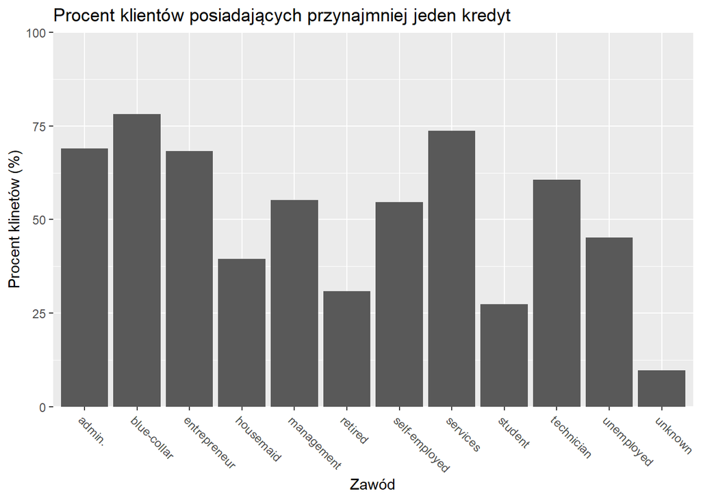

```r
loan_summary <- df %>%
  group_by(job) %>%
  summarise(total_clients = n(),
            either_loans_pct = mean(housing == "yes" | loan == "yes") * 100)

ggplot(loan_summary, aes(x = job, y = either_loans_pct)) +
  geom_col() +
  labs(title = "Procent klientów posiadających przynajmniej jeden kredyt",
       x = "Zawód",
       y = "Procent klinetów (%)") +
  theme(axis.text.x = element_text(angle = -45, hjust = 0), legend.position = "none") +
  scale_y_continuous(expand = c(0, 0), limits = c(0, 100))
```

**Komentarz:**

# Studenci i osoby na emeryturze wyróżniają się tym, że mniejsza część wśród tych osób posiada kredyty # Najwięcej kredytów mają pracownicy fizyczni, ale nie jest to szególnie duża różnica

## Zadanie 2

Wybierając klientów, którzy mają nieznany sposób kontaktu (`contact`). Jak rozkłada się ich wiek w podziale na status związku?

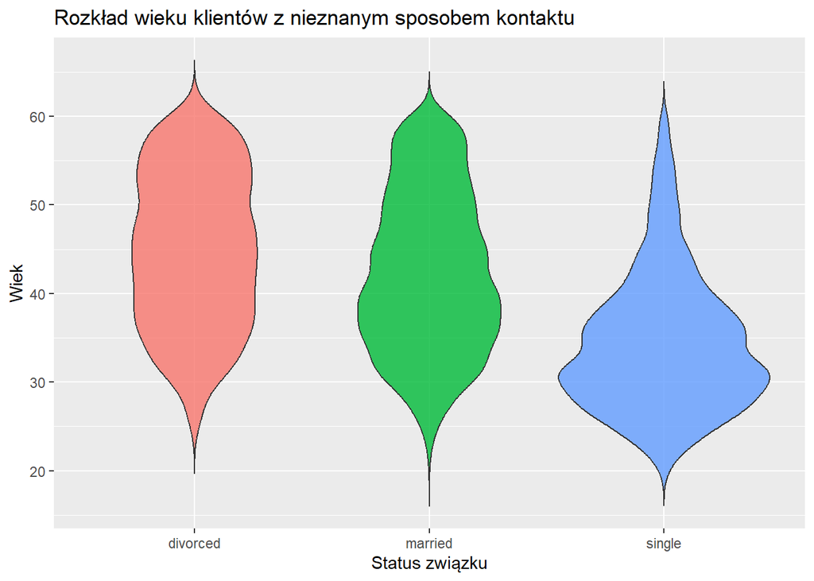

```r
# Tu umieść kod do wygenerowania odpowiedzi do zadania.
df_unknown <- df %>%
  filter(contact == "unknown")

ggplot(df_unknown, aes(x = marital, y = age, fill = marital)) +
  geom_violin(trim = FALSE, alpha = 0.8) +
  labs(title = "Rozkład wieku klientów z nieznanym sposobem kontaktu",
       x = "Status związku",
       y = "Wiek") +
  theme(legend.position = "none")
```

**Komentarz:**

# Wsród osób po rozwodzie osoby z nieznanym sposobem kontaktu są stosunkowo równomiernie rozłożone # w przedziale wieku od 30 do 60 lat. # Osoby żonate/mężate podobnie, aczkolwiek po 40 roku życia pojawia się coraz mniej osób z nieznanym # sposobem kontaktu. # W przypadku singli osób z nieznanym sposobem kontaktu najwięcej jest w wieku 30 lat i większość z # nich mieści się w kategorii między 25, a 40 rokiem życia

## Zadanie 3

Jaka jest różnica pomiędzy średnim rocznym saldem w euro w zależności od wykształcenia i tego czy kredyt jest niespłacany?

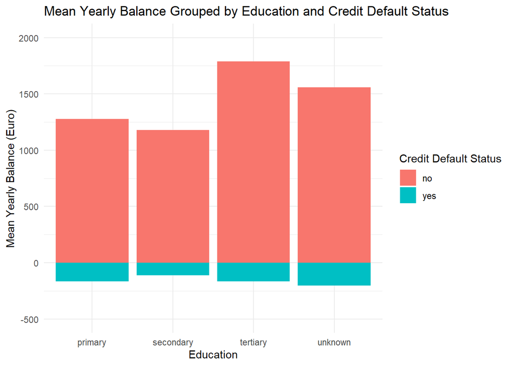

```r
# Tu umieść kod do wygenerowania odpowiedzi do zadania.

balance_summary <- df %>%
  group_by(education, default) %>%
  summarise(mean_balance = mean(balance, na.rm = TRUE))


ggplot(balance_summary, aes(x = education, y = mean_balance, fill = default)) +
  geom_col() +
  labs(title = "Mean Yearly Balance Grouped by Education and Credit Default Status",
       x = "Education",
       y = "Mean Yearly Balance (Euro)",
       fill = "Credit Default Status") +
  theme_minimal() +
  ylim(-500, 2000)
```

**Komentarz:** # Osoby z wyższym wykształceniem mają najwyższe średnie saldo,podczas gdy osoby z wykształceniem # podstawowym i średnim osiągają niższe wartości. # Niezależnie od poziomu edukacji, osoby z zaległościami kredytowymi # mają niższe średnie saldo w porównaniu do tych bez nich.

## Zadanie 4

Czy dzień i miesiąc kontaktu z klientem ma wpływ na średni czas trwania rozmowy w stosunku do średniego czasu trwania rozmowy?

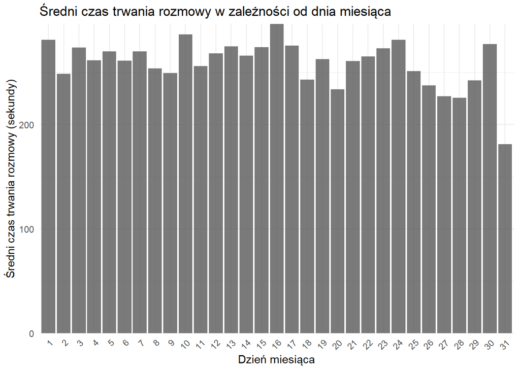

```r
# Tu umieść kod do wygenerowania odpowiedzi do zadania.

duration_by_day <- df %>%
  group_by(day) %>%
  summarise(mean_duration = mean(duration, na.rm = TRUE))

duration_by_month <- df %>%
  group_by(month) %>%
  summarise(mean_duration = mean(duration, na.rm = TRUE))

duration_by_month$month <- factor(duration_by_month$month,
                                  levels = c("jan", "feb", "mar", "apr", "may", "jun",
                                             "jul", "aug", "sep", "oct", "nov", "dec"))


ggplot(duration_by_day, aes(x = as.factor(day), y = mean_duration)) +
  geom_col(alpha = 0.8) +
  labs(title = "Średni czas trwania rozmowy w zależności od dnia miesiąca",
       x = "Dzień miesiąca",
       y = "Średni czas trwania rozmowy (sekundy)",
       fill = "Dzień") +
  theme_minimal() +
  theme(axis.text.x = element_text(angle = 45, hjust = 1)) +
  scale_y_continuous(expand = c(0, 0)) +
  theme(legend.position = "none")
```

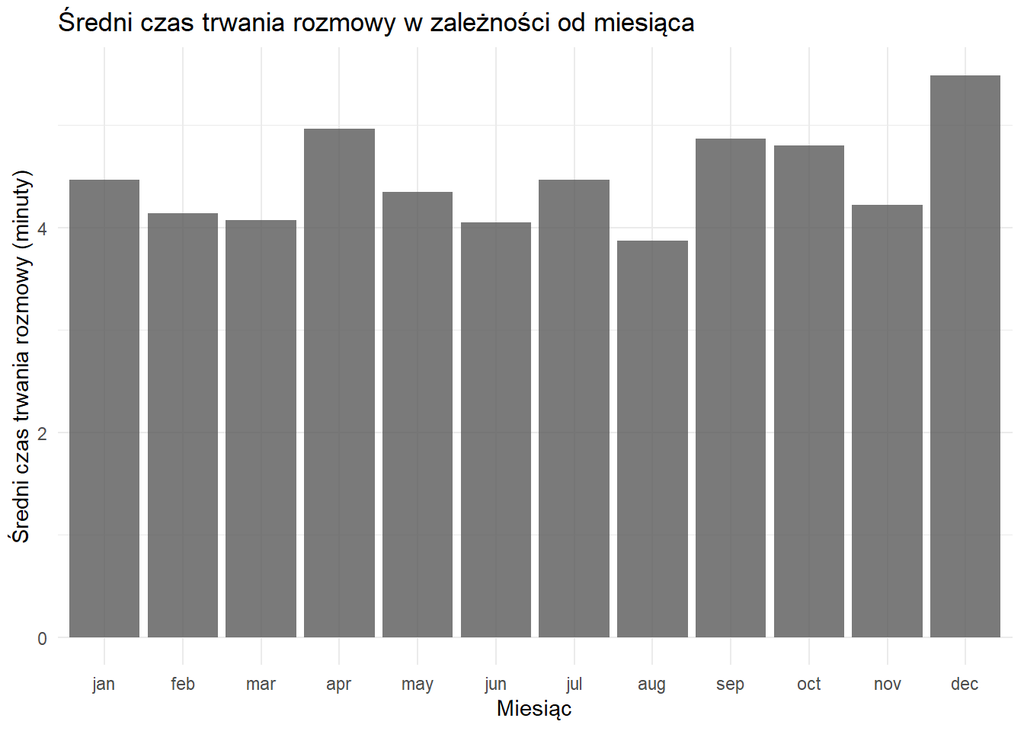

```r
ggplot(duration_by_month, aes(x = month, y = mean_duration/60)) +
  geom_col(alpha = 0.8) +
  labs(title = "Średni czas trwania rozmowy w zależności od miesiąca",
       x = "Miesiąc",
       y = "Średni czas trwania rozmowy (minuty)",
       fill = "Miesiąc") +
  theme_minimal()
```

**Komentarz:** # Nie ma szczególnie dużej zależności między dniem miesiąca a dlugością trwania rozmowy # z wyjątkiem 31 dnia w którym średnia długość rozmów jest znacznie krótsza. # Rozmowy w grudniu są nieco dłuższe niż w inne miesiące, a w pozostałych czas trwania # mieści się w zakresie 4-5 minut.

## Zadanie 5

Czy jest zależnośc pomiędzy wiekiem klientów a ich średnim rocznym saldzie w euro w podziale na stopień wykształcenia?

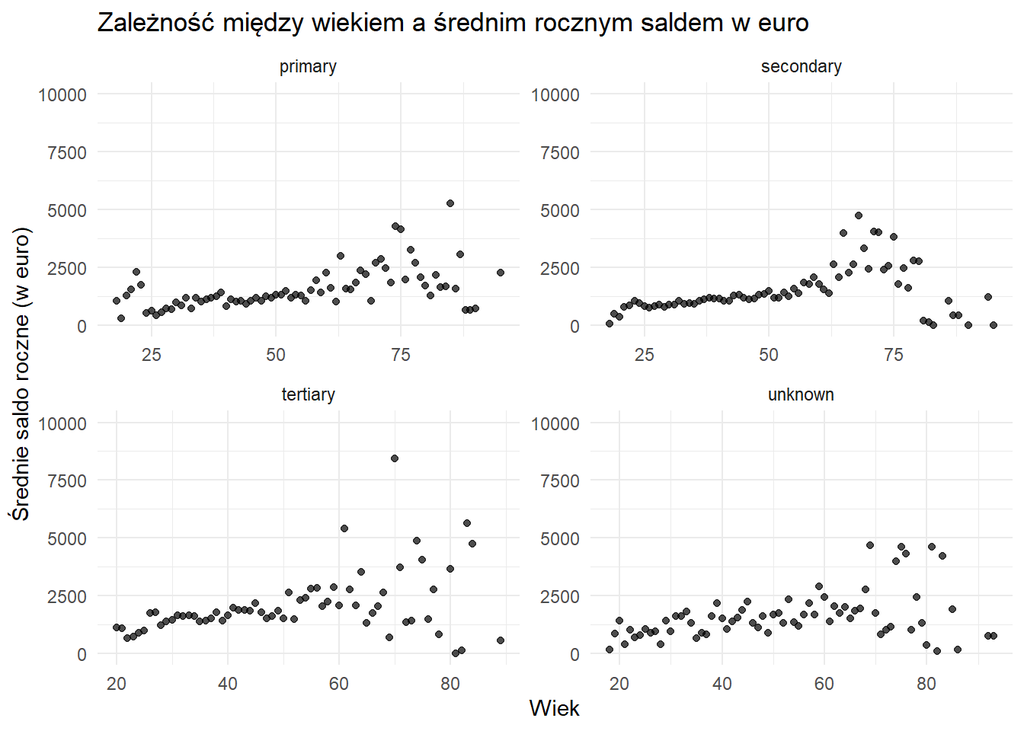

```r
# Tu umieść kod do wygenerowania odpowiedzi do zadania.

age_balance_summary <- df %>%
  group_by(education, age) %>%
  summarise(mean_balance = mean(balance, na.rm = TRUE))

ggplot(age_balance_summary, aes(x = age, y = mean_balance)) +
  geom_point(alpha = 0.7) +
  labs(title = "Zależność między wiekiem a średnim rocznym saldem w euro",
       x = "Wiek",
       y = "Średnie saldo roczne (w euro)") +
  theme_minimal() +
  facet_wrap(~ education, scales = "free") +
  ylim(0, 10000)
```

## Zadanie 6 Rozważmy osoby, które są bezrobotne albo ich zawód jest nieznany.

Czy procent osób, które są bezrobotne i nie spłacają kredytu jest większy od procenta osób o nieznanym zawodzie i nie spłacanym kredycie?

Jaki typ kredytu jest (przez te osoby) najczęściej niespłacany?

```r
# Tu umieść kod do wygenerowania odpowiedzi do zadania.

unemployed_unknown_job <- df %>%
  filter(job %in% c("unknown", "unemployed"))

default_unemployed_unknown_job <- unemployed_unknown_job %>%
  group_by(job) %>%
  summarise(total_clients = n(),
            default_clients = sum(default == "yes"),
            default_pct = (default_clients / total_clients) * 100)  %>%
  print()
```

```
## # A tibble: 2 × 4
##   job        total_clients default_clients default_pct
##   <chr>              <int>           <int>       <dbl>
## 1 unemployed          1303              30       2.30
## 2 unknown              288               2       0.694
```

```r
loan_default_summary <- unemployed_unknown_job %>%
  group_by(job, housing, loan) %>%
  summarise(default_clients = sum(default == "yes"))


loan_default_summary %>%
  filter(default_clients > 0) %>%
  arrange(desc(default_clients)) %>%
  print()
```

```
## # A tibble: 6 × 4
## # Groups:   job, housing [4]
##   job        housing loan  default_clients
##   <chr>      <chr>   <chr>           <int>
## 1 unemployed yes     no                 15
## 2 unemployed no      no                  8
## 3 unemployed yes     yes                 5
## 4 unemployed no      yes                 2
## 5 unknown    no      no                  1
## 6 unknown    yes     no                  1
```

**Komentarz:** # Procent osób, które są bezrobotne i nie spłacają kredytu (2.30) jest większy niż # procent osób o nieznanym zawodzie i nie spłacających kredytu (0.694).

# Przez osoby bezrobotne najczęściej niespłacany jest kredyt mieszkaniowy, tak samo jak # w przypadku osób o nieznanym zawodzie.